# Module 90

#### Contrast SVE:

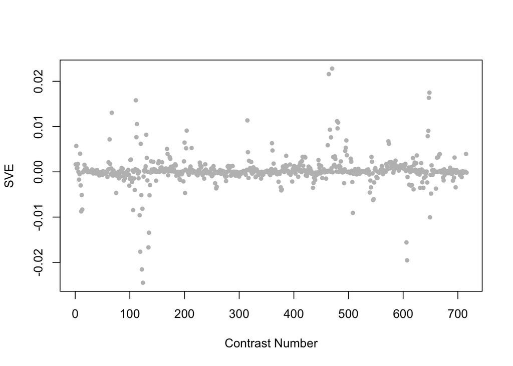

Positive SVE Contrasts:

|  | Contrast.Num | SVE | GEO.GSE | Cond.1 | Cond.2 | Mutation |
| --- | --- | --- | --- | --- | --- | --- |
| GSE23528A.s2t6.vs.s0t6 | 470 | 0.02 | GSE23528 | Adult at T22 in WC, time-series experiment 1 | Adult at T22, non-entrained control time-series experiment 4 |  |
| GSE23528A.s2t4.vs.s0t4 | 464 | 0.02 | GSE23528 | Adult at T14 in WC, time-series experiment 1 | Adult at T14, non-entrained control time-series experiment 4 |  |
| GSE16753.s1t1.vs.s0t1 | 648 | 0.02 | GSE16753 | fer-1 (hc24ts) mutant young adult biological rep 1 | Wild-type young adult biological rep 3 | fer-1 |
| GSE16753.s2t1.vs.s0t1 | 647 | 0.02 | GSE16753 | fer-1 (hc1ts) mutant young adult biological rep 1 | Wild-type young adult biological rep 3 | fer-1 |
| GSE54024.s6t1.vs.s5t1 | 111 | 0.02 | GSE54024 | isp-1(qm150) ced-4(n1162) double mutant young adults, biological rep 1 | ced-4(n1162) young adults, biological rep 1 | isp-1 |

Negative SVE Contrasts:

|  | Contrast.Num | SVE | GEO.GSE | Cond.1 | Cond.2 | Mutation |
| --- | --- | --- | --- | --- | --- | --- |
| GSE54024.s1t1.vs.s3t1 | 124 | -0.02 | GSE54024 | Wild type young adults, biological rep 1 | nuo-6(qm200) young adults, biological rep 1 | nuo-6 |
| GSE54024.s1t1.vs.s4t1 | 122 | -0.02 | GSE54024 | Wild type young adults, biological rep 1 | isp-1(qm150) young adults, biological rep 1 | isp-1 |
| GSE21784.s1t1.vs.s2t1 | 607 | -0.02 | GSE21784 | L4 larvae, biological rep1 | day 6 adults, biological rep 1 |  |
| GSE54024.s1t1.vs.s6t1 | 119 | -0.02 | GSE54024 | Wild type young adults, biological rep 1 | isp-1(qm150) ced-4(n1162) double mutant young adults, biological rep 1 | isp-1;ced-4 |
| GSE52064.s1t1.vs.s4t1 | 134 | -0.02 | GSE52064 | wildtype_1 | lin-54;mes-4_1 | lin-54;mes-4 |

$~$

#### Contrast SVE, Up-Regulated Genes Only:

Calculating SVE for up-regulated and down-regulated genes separately may be more informative in many cases than projecting the up- and down- gene sets together. This is due to the fact that the weight distribution of many modules is highly skewed, indicating that only one of the hemi-modules may be biologically meaningful (i.e., a set of genes are strongly correlated by only a few genes (or none) are strongly anti-correlated to that set.)

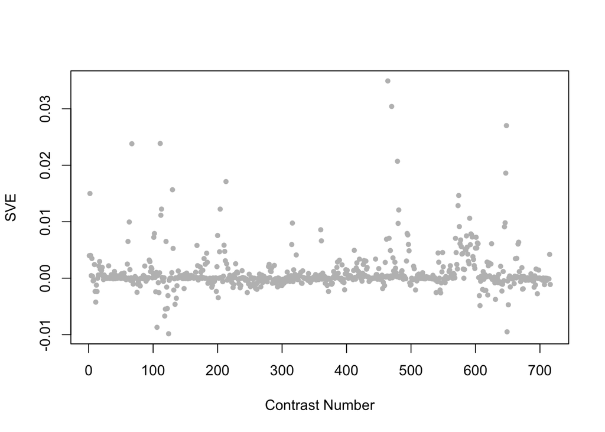

Positive SVE Contrasts:

|  | Contrast.Num | SVE | GEO.GSE | Cond.1 | Cond.2 | Mutation |
| --- | --- | --- | --- | --- | --- | --- |
| GSE23528A.s2t4.vs.s0t4 | 464 | 0.03 | GSE23528 | Adult at T14 in WC, time-series experiment 1 | Adult at T14, non-entrained control time-series experiment 4 |  |
| GSE23528A.s2t6.vs.s0t6 | 470 | 0.03 | GSE23528 | Adult at T22 in WC, time-series experiment 1 | Adult at T22, non-entrained control time-series experiment 4 |  |
| GSE16753.s1t1.vs.s0t1 | 648 | 0.03 | GSE16753 | fer-1 (hc24ts) mutant young adult biological rep 1 | Wild-type young adult biological rep 3 | fer-1 |
| GSE54024.s6t1.vs.s5t1 | 111 | 0.02 | GSE54024 | isp-1(qm150) ced-4(n1162) double mutant young adults, biological rep 1 | ced-4(n1162) young adults, biological rep 1 | isp-1 |
| GSE8659.s3t1.vs.s2t1 | 67 | 0.02 | GSE8659 | strain NL 2099 replicate 2 | strain GR1373 replicate 1 |  |

Negative SVE Contrasts:

|  | Contrast.Num | SVE | GEO.GSE | Cond.1 | Cond.2 | Mutation |
| --- | --- | --- | --- | --- | --- | --- |
| GSE54024.s1t1.vs.s3t1 | 124 | -0.01 | GSE54024 | Wild type young adults, biological rep 1 | nuo-6(qm200) young adults, biological rep 1 | nuo-6 |
| GSE16405.s2t1.vs.s1t1 | 649 | -0.01 | GSE16405 | nth-1_1 | N2_1 | nth-1 |
| GSE54513.s3t1.vs.s1t1 | 106 | -0.01 | GSE54513 | spe-9 input rep1 | fog-1 input rep1 |  |
| GSE54024.s2t1.vs.s6t1 | 118 | -0.01 | GSE54024 | Wild type young adults treated with 0.1mM paraquat, biological rep 1 | isp-1(qm150) ced-4(n1162) double mutant young adults, biological rep 1 |  |
| GSE54024.s1t1.vs.s6t1 | 119 | -0.01 | GSE54024 | Wild type young adults, biological rep 1 | isp-1(qm150) ced-4(n1162) double mutant young adults, biological rep 1 | isp-1;ced-4 |

$~$

#### Contrast SVE, Down-Regulated Genes Only:

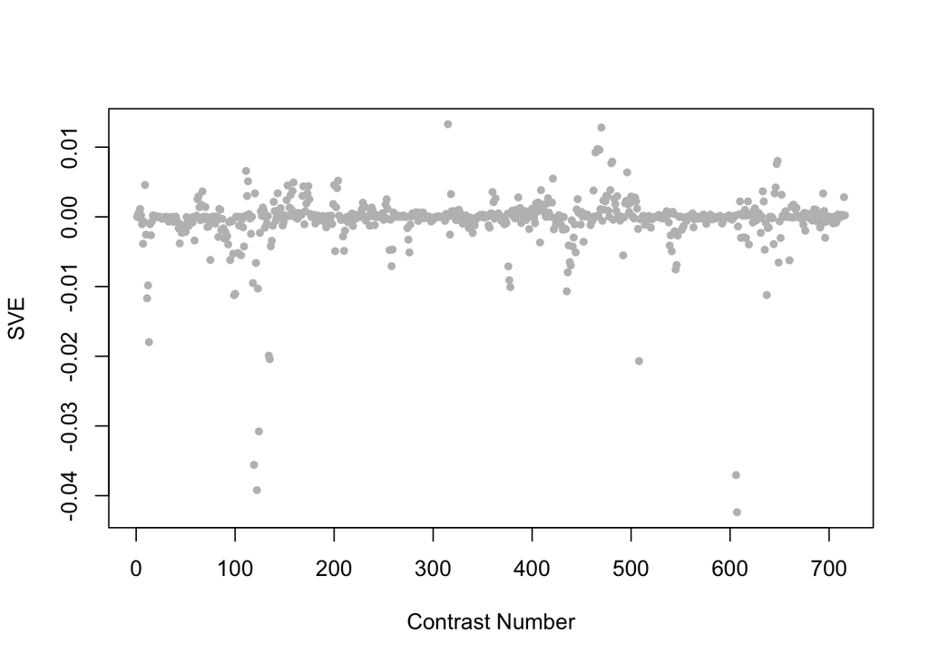

Positive SVE Contrasts:

|  | Contrast.Num | SVE | GEO.GSE | Cond.1 | Cond.2 | Mutation |
| --- | --- | --- | --- | --- | --- | --- |
| GSE40127.s1t1.vs.s0t1 | 315 | 0.01 | GSE40127 | 1E_MK_Celegans_E_1 | 2c_MK_Celegans_Control_2 | gei-8 |
| GSE23528A.s2t6.vs.s0t6 | 470 | 0.01 | GSE23528 | Adult at T22 in WC, time-series experiment 1 | Adult at T22, non-entrained control time-series experiment 4 |  |
| GSE23528A.s2t5.vs.s0t5 | 466 | 0.01 | GSE23528 | Adult at T18 in WC, time-series experiment 1 | Adult at T18, non-entrained control time-series experiment 4 |  |
| GSE23528A.s2t1.vs.s0t1 | 468 | 0.01 | GSE23528 | Adult at T2 in WC, time-series experiment 1 | Adult at T2, non-entrained control time-series experiment 4 |  |
| GSE23528A.s2t4.vs.s0t4 | 464 | 0.01 | GSE23528 | Adult at T14 in WC, time-series experiment 1 | Adult at T14, non-entrained control time-series experiment 4 |  |

Negative SVE Contrasts:

|  | Contrast.Num | SVE | GEO.GSE | Cond.1 | Cond.2 | Mutation |
| --- | --- | --- | --- | --- | --- | --- |
| GSE21784.s1t1.vs.s2t1 | 607 | -0.04 | GSE21784 | L4 larvae, biological rep1 | day 6 adults, biological rep 1 |  |
| GSE54024.s1t1.vs.s4t1 | 122 | -0.04 | GSE54024 | Wild type young adults, biological rep 1 | isp-1(qm150) young adults, biological rep 1 | isp-1 |
| GSE21784.s1t1.vs.s3t1 | 606 | -0.04 | GSE21784 | L4 larvae, biological rep1 | day 15 adults, biological rep 1 |  |
| GSE54024.s1t1.vs.s6t1 | 119 | -0.04 | GSE54024 | Wild type young adults, biological rep 1 | isp-1(qm150) ced-4(n1162) double mutant young adults, biological rep 1 | isp-1;ced-4 |
| GSE54024.s1t1.vs.s3t1 | 124 | -0.03 | GSE54024 | Wild type young adults, biological rep 1 | nuo-6(qm200) young adults, biological rep 1 | nuo-6 |

$~$

$~$

#### GO Term Enrichment:

This analysis tests each hemi-module for enrichment of specific GO terms. Only gene-level annotations (e.g., as would be found on the gene’s page in Wormbase) are tested - the hierarchical structure of the GO ontology is not taken into account.

*Note: At least the top two most enriched terms from each GO domain (BP/MF/CC) are shown, even when not statistically significant.*

##### Enriched GO terms: Hemi-module A

| ID | GO.Term | GO Domain | Raw p-value | Adj p-value |
| --- | --- | --- | --- | --- |
| [GO_0006535](http://amigo.geneontology.org/amigo/term/GO:0006535) | cysteine biosynthetic process from serine | BP | 1.20e-03 | 9.97e-01 |
| [GO_0040015](http://amigo.geneontology.org/amigo/term/GO:0040015) | negative regulation of multicellular organism growth | BP | 1.50e-03 | 9.97e-01 |
| [GO_0004124](http://amigo.geneontology.org/amigo/term/GO:0004124) | cysteine synthase activity | MF | 1.20e-03 | 1.00e+00 |
| [GO_0009918](http://amigo.geneontology.org/amigo/term/GO:0009918) | sterol delta7 reductase activity | MF | 5.90e-03 | 1.00e+00 |
| [GO_0031260](http://amigo.geneontology.org/amigo/term/GO:0031260) | pseudopodium membrane | CC | 1.76e-02 | 9.98e-01 |
| [GO_0045252](http://amigo.geneontology.org/amigo/term/GO:0045252) | oxoglutarate dehydrogenase complex | CC | 1.76e-02 | 9.98e-01 |

##### Enriched GO terms: Hemi-module B

| ID | GO.Term | GO Domain | Raw p-value | Adj p-value |
| --- | --- | --- | --- | --- |
| [GO_0001732](http://amigo.geneontology.org/amigo/term/GO:0001732) | formation of cytoplasmic translation initiation complex | BP | 4.61e-04 | 8.39e-01 |
| [GO_0002183](http://amigo.geneontology.org/amigo/term/GO:0002183) | cytoplasmic translational initiation | BP | 4.61e-04 | 8.39e-01 |
| [GO_0020037](http://amigo.geneontology.org/amigo/term/GO:0020037) | heme binding | MF | 4.12e-04 | 8.42e-01 |
| [GO_0016705](http://amigo.geneontology.org/amigo/term/GO:0016705) | oxidoreductase activity, acting on paired donors, with incorporation or reduction of molecular oxygen | MF | 1.01e-03 | 8.67e-01 |
| [GO_0016282](http://amigo.geneontology.org/amigo/term/GO:0016282) | eukaryotic 43S preinitiation complex | CC | 3.26e-04 | 1.51e-01 |
| [GO_0033290](http://amigo.geneontology.org/amigo/term/GO:0033290) | eukaryotic 48S preinitiation complex | CC | 3.26e-04 | 1.51e-01 |

$~$

$~$

#### Tissue Enrichment:

This analysis tests each hemi-module for enrichment of genes associated with anatomy terms. Negative enrichment scores indicate fewer hemi-module genes than expected by random chance were associated with the anatomy term in question.

##### Enriched tissues: Hemi-module A

No significant annotations.

##### Enriched tissues: Hemi-module B

No significant annotations.

$~$

$~$

#### HOMER promoter motif enrichment:

This analysis tests each hemi-module for enrichment of 108 known *C. elegans* transcription factor binding site motifs (see [108 CE motifs](https://katiepod.github.io//all.worm.motifs.html)) using the HOMER (Hypergeometric Optimization of Motif EnRichment) software (see [PMID:20513432](https://pubmed.ncbi.nlm.nih.gov/20513432)). HOMER was run using default parameters on sequences 1 kb upstream of the transcription start site.

##### Motif enrichment: Hemi-module A

Total target sequences = 103  
Total background sequences = 38297  
* - possible false positive

Rank

Motif

P-value

log P-pvalue

% of Targets

% of Background

STD(Bg STD)

Best Match/Details

Motif File

1 *

[figure not shown]

1e-9

-2.265e+01

5.83%

0.06%

209.9bp (395.2bp)

MF0009.1_TRP(MYB)_class/Jaspar(0.560)  
[More Information](https://katiepod.github.io/HomerResults/m90_a_hemi_genes.txt.out.1kb/homerResults/motif1.info.html) | [Similar Motifs Found](https://katiepod.github.io/HomerResults/m90_a_hemi_genes.txt.out.1kb/homerResults/motif1.similar.html)

[motif file (matrix)](https://katiepod.github.io/HomerResults/m90_a_hemi_genes.txt.out.1kb/homerResults/motif1.motif)

2 *

[figure not shown]

1e-9

-2.239e+01

30.10%

8.35%

242.0bp (329.8bp)

atf-7/MA1438.1/Jaspar(0.572)  
[More Information](https://katiepod.github.io/HomerResults/m90_a_hemi_genes.txt.out.1kb/homerResults/motif2.info.html) | [Similar Motifs Found](https://katiepod.github.io/HomerResults/m90_a_hemi_genes.txt.out.1kb/homerResults/motif2.similar.html)

[motif file (matrix)](https://katiepod.github.io/HomerResults/m90_a_hemi_genes.txt.out.1kb/homerResults/motif2.motif)

3 *

[figure not shown]

1e-9

-2.212e+01

4.85%

0.02%

276.3bp (231.7bp)

POL010.1_DCE_S_III/Jaspar(0.512)  
[More Information](https://katiepod.github.io/HomerResults/m90_a_hemi_genes.txt.out.1kb/homerResults/motif3.info.html) | [Similar Motifs Found](https://katiepod.github.io/HomerResults/m90_a_hemi_genes.txt.out.1kb/homerResults/motif3.similar.html)

[motif file (matrix)](https://katiepod.github.io/HomerResults/m90_a_hemi_genes.txt.out.1kb/homerResults/motif3.motif)

4 *

[figure not shown]

1e-9

-2.087e+01

21.36%

4.44%

225.6bp (311.4bp)

efl-1/MA0541.1/Jaspar(0.535)  
[More Information](https://katiepod.github.io/HomerResults/m90_a_hemi_genes.txt.out.1kb/homerResults/motif4.info.html) | [Similar Motifs Found](https://katiepod.github.io/HomerResults/m90_a_hemi_genes.txt.out.1kb/homerResults/motif4.similar.html)

[motif file (matrix)](https://katiepod.github.io/HomerResults/m90_a_hemi_genes.txt.out.1kb/homerResults/motif4.motif)

5 *

[figure not shown]

1e-8

-2.000e+01

9.71%

0.65%

195.6bp (307.5bp)

POL008.1_DCE_S_I/Jaspar(0.598)  
[More Information](https://katiepod.github.io/HomerResults/m90_a_hemi_genes.txt.out.1kb/homerResults/motif5.info.html) | [Similar Motifs Found](https://katiepod.github.io/HomerResults/m90_a_hemi_genes.txt.out.1kb/homerResults/motif5.similar.html)

[motif file (matrix)](https://katiepod.github.io/HomerResults/m90_a_hemi_genes.txt.out.1kb/homerResults/motif5.motif)

6 *

[figure not shown]

1e-8

-1.996e+01

8.74%

0.47%

295.7bp (344.9bp)

LIN-39(Homeobox)/cElegans.L3-LIN39-ChIP-Seq(modEncode)/Homer(0.641)  
[More Information](https://katiepod.github.io/HomerResults/m90_a_hemi_genes.txt.out.1kb/homerResults/motif6.info.html) | [Similar Motifs Found](https://katiepod.github.io/HomerResults/m90_a_hemi_genes.txt.out.1kb/homerResults/motif6.similar.html)

[motif file (matrix)](https://katiepod.github.io/HomerResults/m90_a_hemi_genes.txt.out.1kb/homerResults/motif6.motif)

7 *

[figure not shown]

1e-8

-1.986e+01

10.68%

0.87%

280.3bp (315.7bp)

unc-30/MA1443.1/Jaspar(0.735)  
[More Information](https://katiepod.github.io/HomerResults/m90_a_hemi_genes.txt.out.1kb/homerResults/motif7.info.html) | [Similar Motifs Found](https://katiepod.github.io/HomerResults/m90_a_hemi_genes.txt.out.1kb/homerResults/motif7.similar.html)

[motif file (matrix)](https://katiepod.github.io/HomerResults/m90_a_hemi_genes.txt.out.1kb/homerResults/motif7.motif)

8 *

[figure not shown]

1e-8

-1.985e+01

5.83%

0.10%

311.0bp (333.9bp)

POL009.1_DCE_S_II/Jaspar(0.467)  
[More Information](https://katiepod.github.io/HomerResults/m90_a_hemi_genes.txt.out.1kb/homerResults/motif8.info.html) | [Similar Motifs Found](https://katiepod.github.io/HomerResults/m90_a_hemi_genes.txt.out.1kb/homerResults/motif8.similar.html)

[motif file (matrix)](https://katiepod.github.io/HomerResults/m90_a_hemi_genes.txt.out.1kb/homerResults/motif8.motif)

9 *

[figure not shown]

1e-8

-1.922e+01

10.68%

0.93%

222.0bp (322.9bp)

SD0002.1_at_AC_acceptor/Jaspar(0.561)  
[More Information](https://katiepod.github.io/HomerResults/m90_a_hemi_genes.txt.out.1kb/homerResults/motif9.info.html) | [Similar Motifs Found](https://katiepod.github.io/HomerResults/m90_a_hemi_genes.txt.out.1kb/homerResults/motif9.similar.html)

[motif file (matrix)](https://katiepod.github.io/HomerResults/m90_a_hemi_genes.txt.out.1kb/homerResults/motif9.motif)

10 *

[figure not shown]

1e-7

-1.723e+01

4.85%

0.08%

298.0bp (290.4bp)

SD0003.1_at_AC_acceptor/Jaspar(0.525)  
[More Information](https://katiepod.github.io/HomerResults/m90_a_hemi_genes.txt.out.1kb/homerResults/motif10.info.html) | [Similar Motifs Found](https://katiepod.github.io/HomerResults/m90_a_hemi_genes.txt.out.1kb/homerResults/motif10.similar.html)

[motif file (matrix)](https://katiepod.github.io/HomerResults/m90_a_hemi_genes.txt.out.1kb/homerResults/motif10.motif)

11 *

[figure not shown]

1e-6

-1.523e+01

10.68%

1.38%

281.2bp (305.8bp)

unc-30/MA1443.1/Jaspar(0.592)  
[More Information](https://katiepod.github.io/HomerResults/m90_a_hemi_genes.txt.out.1kb/homerResults/motif11.info.html) | [Similar Motifs Found](https://katiepod.github.io/HomerResults/m90_a_hemi_genes.txt.out.1kb/homerResults/motif11.similar.html)

[motif file (matrix)](https://katiepod.github.io/HomerResults/m90_a_hemi_genes.txt.out.1kb/homerResults/motif11.motif)

12 *

[figure not shown]

1e-6

-1.494e+01

33.01%

13.44%

255.0bp (309.4bp)

fkh-2/MA0920.1/Jaspar(0.632)  
[More Information](https://katiepod.github.io/HomerResults/m90_a_hemi_genes.txt.out.1kb/homerResults/motif12.info.html) | [Similar Motifs Found](https://katiepod.github.io/HomerResults/m90_a_hemi_genes.txt.out.1kb/homerResults/motif12.similar.html)

[motif file (matrix)](https://katiepod.github.io/HomerResults/m90_a_hemi_genes.txt.out.1kb/homerResults/motif12.motif)

13 *

[figure not shown]

1e-6

-1.484e+01

4.85%

0.13%

260.0bp (302.1bp)

daf-16/MA1446.1/Jaspar(0.593)  
[More Information](https://katiepod.github.io/HomerResults/m90_a_hemi_genes.txt.out.1kb/homerResults/motif13.info.html) | [Similar Motifs Found](https://katiepod.github.io/HomerResults/m90_a_hemi_genes.txt.out.1kb/homerResults/motif13.similar.html)

[motif file (matrix)](https://katiepod.github.io/HomerResults/m90_a_hemi_genes.txt.out.1kb/homerResults/motif13.motif)

14 *

[figure not shown]

1e-6

-1.452e+01

5.83%

0.27%

245.4bp (289.6bp)

fkh-9/MA1440.1/Jaspar(0.643)  
[More Information](https://katiepod.github.io/HomerResults/m90_a_hemi_genes.txt.out.1kb/homerResults/motif14.info.html) | [Similar Motifs Found](https://katiepod.github.io/HomerResults/m90_a_hemi_genes.txt.out.1kb/homerResults/motif14.similar.html)

[motif file (matrix)](https://katiepod.github.io/HomerResults/m90_a_hemi_genes.txt.out.1kb/homerResults/motif14.motif)

15 *

[figure not shown]

1e-6

-1.410e+01

9.71%

1.24%

300.5bp (307.2bp)

fkh-2/MA0920.1/Jaspar(0.594)  
[More Information](https://katiepod.github.io/HomerResults/m90_a_hemi_genes.txt.out.1kb/homerResults/motif15.info.html) | [Similar Motifs Found](https://katiepod.github.io/HomerResults/m90_a_hemi_genes.txt.out.1kb/homerResults/motif15.similar.html)

[motif file (matrix)](https://katiepod.github.io/HomerResults/m90_a_hemi_genes.txt.out.1kb/homerResults/motif15.motif)

16 *

[figure not shown]

1e-5

-1.371e+01

8.74%

0.99%

224.1bp (325.7bp)

snpc-4/MA0544.1/Jaspar(0.676)  
[More Information](https://katiepod.github.io/HomerResults/m90_a_hemi_genes.txt.out.1kb/homerResults/motif16.info.html) | [Similar Motifs Found](https://katiepod.github.io/HomerResults/m90_a_hemi_genes.txt.out.1kb/homerResults/motif16.similar.html)

[motif file (matrix)](https://katiepod.github.io/HomerResults/m90_a_hemi_genes.txt.out.1kb/homerResults/motif16.motif)

17 *

[figure not shown]

1e-5

-1.369e+01

14.56%

3.20%

238.4bp (305.9bp)

unc-86/MA0926.1/Jaspar(0.561)  
[More Information](https://katiepod.github.io/HomerResults/m90_a_hemi_genes.txt.out.1kb/homerResults/motif17.info.html) | [Similar Motifs Found](https://katiepod.github.io/HomerResults/m90_a_hemi_genes.txt.out.1kb/homerResults/motif17.similar.html)

[motif file (matrix)](https://katiepod.github.io/HomerResults/m90_a_hemi_genes.txt.out.1kb/homerResults/motif17.motif)

18 *

[figure not shown]

1e-5

-1.310e+01

9.71%

1.38%

131.6bp (310.1bp)

lin-54/MA1450.1/Jaspar(0.612)  
[More Information](https://katiepod.github.io/HomerResults/m90_a_hemi_genes.txt.out.1kb/homerResults/motif18.info.html) | [Similar Motifs Found](https://katiepod.github.io/HomerResults/m90_a_hemi_genes.txt.out.1kb/homerResults/motif18.similar.html)

[motif file (matrix)](https://katiepod.github.io/HomerResults/m90_a_hemi_genes.txt.out.1kb/homerResults/motif18.motif)

19 *

[figure not shown]

1e-5

-1.310e+01

12.62%

2.50%

305.3bp (318.4bp)

fos-1/MA1448.1/Jaspar(0.601)  
[More Information](https://katiepod.github.io/HomerResults/m90_a_hemi_genes.txt.out.1kb/homerResults/motif19.info.html) | [Similar Motifs Found](https://katiepod.github.io/HomerResults/m90_a_hemi_genes.txt.out.1kb/homerResults/motif19.similar.html)

[motif file (matrix)](https://katiepod.github.io/HomerResults/m90_a_hemi_genes.txt.out.1kb/homerResults/motif19.motif)

20 *

[figure not shown]

1e-5

-1.255e+01

26.21%

10.22%

227.6bp (361.2bp)

DPL-1(E2F)/cElegans-Adult-ChIP-Seq(modEncode)/Homer(0.866)  
[More Information](https://katiepod.github.io/HomerResults/m90_a_hemi_genes.txt.out.1kb/homerResults/motif20.info.html) | [Similar Motifs Found](https://katiepod.github.io/HomerResults/m90_a_hemi_genes.txt.out.1kb/homerResults/motif20.similar.html)

[motif file (matrix)](https://katiepod.github.io/HomerResults/m90_a_hemi_genes.txt.out.1kb/homerResults/motif20.motif)

21 *

[figure not shown]

1e-5

-1.196e+01

10.68%

1.95%

281.0bp (359.6bp)

POL013.1_MED-1/Jaspar(0.757)  
[More Information](https://katiepod.github.io/HomerResults/m90_a_hemi_genes.txt.out.1kb/homerResults/motif21.info.html) | [Similar Motifs Found](https://katiepod.github.io/HomerResults/m90_a_hemi_genes.txt.out.1kb/homerResults/motif21.similar.html)

[motif file (matrix)](https://katiepod.github.io/HomerResults/m90_a_hemi_genes.txt.out.1kb/homerResults/motif21.motif)

22 *

[figure not shown]

1e-5

-1.196e+01

10.68%

1.95%

312.7bp (299.6bp)

lin-54/MA1450.1/Jaspar(0.559)  
[More Information](https://katiepod.github.io/HomerResults/m90_a_hemi_genes.txt.out.1kb/homerResults/motif22.info.html) | [Similar Motifs Found](https://katiepod.github.io/HomerResults/m90_a_hemi_genes.txt.out.1kb/homerResults/motif22.similar.html)

[motif file (matrix)](https://katiepod.github.io/HomerResults/m90_a_hemi_genes.txt.out.1kb/homerResults/motif22.motif)

23 *

[figure not shown]

1e-4

-1.130e+01

2.91%

0.04%

119.9bp (265.1bp)

pha-4/MA0546.1/Jaspar(0.610)  
[More Information](https://katiepod.github.io/HomerResults/m90_a_hemi_genes.txt.out.1kb/homerResults/motif23.info.html) | [Similar Motifs Found](https://katiepod.github.io/HomerResults/m90_a_hemi_genes.txt.out.1kb/homerResults/motif23.similar.html)

[motif file (matrix)](https://katiepod.github.io/HomerResults/m90_a_hemi_genes.txt.out.1kb/homerResults/motif23.motif)

24 *

[figure not shown]

1e-4

-1.104e+01

3.88%

0.14%

199.3bp (261.1bp)

ceh-48/MA0921.1/Jaspar(0.516)  
[More Information](https://katiepod.github.io/HomerResults/m90_a_hemi_genes.txt.out.1kb/homerResults/motif24.info.html) | [Similar Motifs Found](https://katiepod.github.io/HomerResults/m90_a_hemi_genes.txt.out.1kb/homerResults/motif24.similar.html)

[motif file (matrix)](https://katiepod.github.io/HomerResults/m90_a_hemi_genes.txt.out.1kb/homerResults/motif24.motif)

25 *

[figure not shown]

1e-4

-1.011e+01

9.71%

1.97%

285.2bp (310.8bp)

zip-8/MA1704.1/Jaspar(0.855)  
[More Information](https://katiepod.github.io/HomerResults/m90_a_hemi_genes.txt.out.1kb/homerResults/motif25.info.html) | [Similar Motifs Found](https://katiepod.github.io/HomerResults/m90_a_hemi_genes.txt.out.1kb/homerResults/motif25.similar.html)

[motif file (matrix)](https://katiepod.github.io/HomerResults/m90_a_hemi_genes.txt.out.1kb/homerResults/motif25.motif)

26 *

[figure not shown]

1e-3

-9.093e+00

12.62%

3.68%

262.4bp (319.7bp)

cebp-1/MA1444.1/Jaspar(0.624)  
[More Information](https://katiepod.github.io/HomerResults/m90_a_hemi_genes.txt.out.1kb/homerResults/motif26.info.html) | [Similar Motifs Found](https://katiepod.github.io/HomerResults/m90_a_hemi_genes.txt.out.1kb/homerResults/motif26.similar.html)

[motif file (matrix)](https://katiepod.github.io/HomerResults/m90_a_hemi_genes.txt.out.1kb/homerResults/motif26.motif)

27 *

[figure not shown]

1e-3

-8.105e+00

8.74%

2.06%

296.7bp (320.2bp)

ceh-28/MA1445.1/Jaspar(0.698)  
[More Information](https://katiepod.github.io/HomerResults/m90_a_hemi_genes.txt.out.1kb/homerResults/motif27.info.html) | [Similar Motifs Found](https://katiepod.github.io/HomerResults/m90_a_hemi_genes.txt.out.1kb/homerResults/motif27.similar.html)

[motif file (matrix)](https://katiepod.github.io/HomerResults/m90_a_hemi_genes.txt.out.1kb/homerResults/motif27.motif)

28 *

[figure not shown]

1e-2

-6.595e+00

7.77%

2.05%

259.2bp (351.3bp)

POL003.1_GC-box/Jaspar(0.787)  
[More Information](https://katiepod.github.io/HomerResults/m90_a_hemi_genes.txt.out.1kb/homerResults/motif28.info.html) | [Similar Motifs Found](https://katiepod.github.io/HomerResults/m90_a_hemi_genes.txt.out.1kb/homerResults/motif28.similar.html)

[motif file (matrix)](https://katiepod.github.io/HomerResults/m90_a_hemi_genes.txt.out.1kb/homerResults/motif28.motif)

29 *

[figure not shown]

1e-2

-6.284e+00

6.80%

1.68%

132.8bp (324.8bp)

blmp-1/MA0537.1/Jaspar(0.550)  
[More Information](https://katiepod.github.io/HomerResults/m90_a_hemi_genes.txt.out.1kb/homerResults/motif29.info.html) | [Similar Motifs Found](https://katiepod.github.io/HomerResults/m90_a_hemi_genes.txt.out.1kb/homerResults/motif29.similar.html)

[motif file (matrix)](https://katiepod.github.io/HomerResults/m90_a_hemi_genes.txt.out.1kb/homerResults/motif29.motif)

30 *

[figure not shown]

1e-1

-2.956e+00

67.96%

59.67%

270.5bp (310.9bp)

ceh-28/MA1445.1/Jaspar(0.653)  
[More Information](https://katiepod.github.io/HomerResults/m90_a_hemi_genes.txt.out.1kb/homerResults/motif30.info.html) | [Similar Motifs Found](https://katiepod.github.io/HomerResults/m90_a_hemi_genes.txt.out.1kb/homerResults/motif30.similar.html)

[motif file (matrix)](https://katiepod.github.io/HomerResults/m90_a_hemi_genes.txt.out.1kb/homerResults/motif30.motif)

##### Motif enrichment: Hemi-module B

Total target sequences = 31  
Total background sequences = 38211  
* - possible false positive

Rank

Motif

P-value

log P-pvalue

% of Targets

% of Background

STD(Bg STD)

Best Match/Details

Motif File

1 *

[figure not shown]

1e-10

-2.364e+01

32.26%

1.66%

215.9bp (304.7bp)

POL002.1_INR/Jaspar(0.463)  
[More Information](https://katiepod.github.io/HomerResults/m90_b_hemi_genes.txt.out.1kb/homerResults/motif1.info.html) | [Similar Motifs Found](https://katiepod.github.io/HomerResults/m90_b_hemi_genes.txt.out.1kb/homerResults/motif1.similar.html)

[motif file (matrix)](https://katiepod.github.io/HomerResults/m90_b_hemi_genes.txt.out.1kb/homerResults/motif1.motif)

2 *

[figure not shown]

1e-8

-1.948e+01

22.58%

0.76%

325.1bp (304.7bp)

lin-14/MA0261.1/Jaspar(0.610)  
[More Information](https://katiepod.github.io/HomerResults/m90_b_hemi_genes.txt.out.1kb/homerResults/motif2.info.html) | [Similar Motifs Found](https://katiepod.github.io/HomerResults/m90_b_hemi_genes.txt.out.1kb/homerResults/motif2.similar.html)

[motif file (matrix)](https://katiepod.github.io/HomerResults/m90_b_hemi_genes.txt.out.1kb/homerResults/motif2.motif)

3 *

[figure not shown]

1e-8

-1.919e+01

22.58%

0.79%

323.7bp (323.2bp)

sma-4/MA0925.1/Jaspar(0.601)  
[More Information](https://katiepod.github.io/HomerResults/m90_b_hemi_genes.txt.out.1kb/homerResults/motif3.info.html) | [Similar Motifs Found](https://katiepod.github.io/HomerResults/m90_b_hemi_genes.txt.out.1kb/homerResults/motif3.similar.html)

[motif file (matrix)](https://katiepod.github.io/HomerResults/m90_b_hemi_genes.txt.out.1kb/homerResults/motif3.motif)

4 *

[figure not shown]

1e-8

-1.843e+01

22.58%

0.89%

277.6bp (296.3bp)

MF0005.1_Forkhead_class/Jaspar(0.647)  
[More Information](https://katiepod.github.io/HomerResults/m90_b_hemi_genes.txt.out.1kb/homerResults/motif4.info.html) | [Similar Motifs Found](https://katiepod.github.io/HomerResults/m90_b_hemi_genes.txt.out.1kb/homerResults/motif4.similar.html)

[motif file (matrix)](https://katiepod.github.io/HomerResults/m90_b_hemi_genes.txt.out.1kb/homerResults/motif4.motif)

5 *

[figure not shown]

1e-7

-1.772e+01

12.90%

0.09%

163.4bp (212.5bp)

ceh-48/MA0921.1/Jaspar(0.643)  
[More Information](https://katiepod.github.io/HomerResults/m90_b_hemi_genes.txt.out.1kb/homerResults/motif5.info.html) | [Similar Motifs Found](https://katiepod.github.io/HomerResults/m90_b_hemi_genes.txt.out.1kb/homerResults/motif5.similar.html)

[motif file (matrix)](https://katiepod.github.io/HomerResults/m90_b_hemi_genes.txt.out.1kb/homerResults/motif5.motif)

6 *

[figure not shown]

1e-7

-1.755e+01

41.94%

6.46%

254.5bp (311.1bp)

unc-86/MA0926.1/Jaspar(0.625)  
[More Information](https://katiepod.github.io/HomerResults/m90_b_hemi_genes.txt.out.1kb/homerResults/motif6.info.html) | [Similar Motifs Found](https://katiepod.github.io/HomerResults/m90_b_hemi_genes.txt.out.1kb/homerResults/motif6.similar.html)

[motif file (matrix)](https://katiepod.github.io/HomerResults/m90_b_hemi_genes.txt.out.1kb/homerResults/motif6.motif)

7 *

[figure not shown]

1e-7

-1.680e+01

22.58%

1.13%

221.1bp (302.6bp)

PL0001.1_hlh-11/Jaspar(0.616)  
[More Information](https://katiepod.github.io/HomerResults/m90_b_hemi_genes.txt.out.1kb/homerResults/motif7.info.html) | [Similar Motifs Found](https://katiepod.github.io/HomerResults/m90_b_hemi_genes.txt.out.1kb/homerResults/motif7.similar.html)

[motif file (matrix)](https://katiepod.github.io/HomerResults/m90_b_hemi_genes.txt.out.1kb/homerResults/motif7.motif)

8 *

[figure not shown]

1e-7

-1.621e+01

16.13%

0.35%

286.2bp (329.7bp)

mab-5/MA1442.1/Jaspar(0.562)  
[More Information](https://katiepod.github.io/HomerResults/m90_b_hemi_genes.txt.out.1kb/homerResults/motif8.info.html) | [Similar Motifs Found](https://katiepod.github.io/HomerResults/m90_b_hemi_genes.txt.out.1kb/homerResults/motif8.similar.html)

[motif file (matrix)](https://katiepod.github.io/HomerResults/m90_b_hemi_genes.txt.out.1kb/homerResults/motif8.motif)

9 *

[figure not shown]

1e-6

-1.595e+01

45.16%

8.88%

281.7bp (305.1bp)

MF0006.1_bZIP_cEBP-like_subclass/Jaspar(0.618)  
[More Information](https://katiepod.github.io/HomerResults/m90_b_hemi_genes.txt.out.1kb/homerResults/motif9.info.html) | [Similar Motifs Found](https://katiepod.github.io/HomerResults/m90_b_hemi_genes.txt.out.1kb/homerResults/motif9.similar.html)

[motif file (matrix)](https://katiepod.github.io/HomerResults/m90_b_hemi_genes.txt.out.1kb/homerResults/motif9.motif)

10 *

[figure not shown]

1e-6

-1.476e+01

25.81%

2.29%

282.9bp (316.3bp)

daf-16/MA1446.1/Jaspar(0.616)  
[More Information](https://katiepod.github.io/HomerResults/m90_b_hemi_genes.txt.out.1kb/homerResults/motif10.info.html) | [Similar Motifs Found](https://katiepod.github.io/HomerResults/m90_b_hemi_genes.txt.out.1kb/homerResults/motif10.similar.html)

[motif file (matrix)](https://katiepod.github.io/HomerResults/m90_b_hemi_genes.txt.out.1kb/homerResults/motif10.motif)

11 *

[figure not shown]

1e-6

-1.416e+01

48.39%

12.01%

317.3bp (305.1bp)

lin-54/MA1450.1/Jaspar(0.651)  
[More Information](https://katiepod.github.io/HomerResults/m90_b_hemi_genes.txt.out.1kb/homerResults/motif11.info.html) | [Similar Motifs Found](https://katiepod.github.io/HomerResults/m90_b_hemi_genes.txt.out.1kb/homerResults/motif11.similar.html)

[motif file (matrix)](https://katiepod.github.io/HomerResults/m90_b_hemi_genes.txt.out.1kb/homerResults/motif11.motif)

12 *

[figure not shown]

1e-5

-1.323e+01

16.13%

0.65%

252.3bp (312.3bp)

ceh-38/MA1699.1/Jaspar(0.730)  
[More Information](https://katiepod.github.io/HomerResults/m90_b_hemi_genes.txt.out.1kb/homerResults/motif12.info.html) | [Similar Motifs Found](https://katiepod.github.io/HomerResults/m90_b_hemi_genes.txt.out.1kb/homerResults/motif12.similar.html)

[motif file (matrix)](https://katiepod.github.io/HomerResults/m90_b_hemi_genes.txt.out.1kb/homerResults/motif12.motif)

13 *

[figure not shown]

1e-5

-1.235e+01

16.13%

0.78%

257.4bp (281.5bp)

pal-1/MA0924.1/Jaspar(0.637)  
[More Information](https://katiepod.github.io/HomerResults/m90_b_hemi_genes.txt.out.1kb/homerResults/motif13.info.html) | [Similar Motifs Found](https://katiepod.github.io/HomerResults/m90_b_hemi_genes.txt.out.1kb/homerResults/motif13.similar.html)

[motif file (matrix)](https://katiepod.github.io/HomerResults/m90_b_hemi_genes.txt.out.1kb/homerResults/motif13.motif)

14 *

[figure not shown]

1e-5

-1.214e+01

9.68%

0.10%

113.1bp (319.2bp)

ces-2/MA0922.1/Jaspar(0.720)  
[More Information](https://katiepod.github.io/HomerResults/m90_b_hemi_genes.txt.out.1kb/homerResults/motif14.info.html) | [Similar Motifs Found](https://katiepod.github.io/HomerResults/m90_b_hemi_genes.txt.out.1kb/homerResults/motif14.similar.html)

[motif file (matrix)](https://katiepod.github.io/HomerResults/m90_b_hemi_genes.txt.out.1kb/homerResults/motif14.motif)

15 *

[figure not shown]

1e-3

-7.522e+00

12.90%

1.22%

299.0bp (313.0bp)

ceh-38/MA1699.1/Jaspar(0.717)  
[More Information](https://katiepod.github.io/HomerResults/m90_b_hemi_genes.txt.out.1kb/homerResults/motif15.info.html) | [Similar Motifs Found](https://katiepod.github.io/HomerResults/m90_b_hemi_genes.txt.out.1kb/homerResults/motif15.similar.html)

[motif file (matrix)](https://katiepod.github.io/HomerResults/m90_b_hemi_genes.txt.out.1kb/homerResults/motif15.motif)

16 *

[figure not shown]

1e-3

-7.132e+00

70.97%

41.27%

290.7bp (312.2bp)

POL002.1_INR/Jaspar(0.598)  
[More Information](https://katiepod.github.io/HomerResults/m90_b_hemi_genes.txt.out.1kb/homerResults/motif16.info.html) | [Similar Motifs Found](https://katiepod.github.io/HomerResults/m90_b_hemi_genes.txt.out.1kb/homerResults/motif16.similar.html)

[motif file (matrix)](https://katiepod.github.io/HomerResults/m90_b_hemi_genes.txt.out.1kb/homerResults/motif16.motif)

17 *

[figure not shown]

1e-2

-5.907e+00

19.35%

4.64%

202.8bp (340.7bp)

eor-1/MA0543.1/Jaspar(0.772)  
[More Information](https://katiepod.github.io/HomerResults/m90_b_hemi_genes.txt.out.1kb/homerResults/motif17.info.html) | [Similar Motifs Found](https://katiepod.github.io/HomerResults/m90_b_hemi_genes.txt.out.1kb/homerResults/motif17.similar.html)

[motif file (matrix)](https://katiepod.github.io/HomerResults/m90_b_hemi_genes.txt.out.1kb/homerResults/motif17.motif)

18 *

[figure not shown]

1e-1

-4.408e+00

12.90%

2.92%

179.4bp (274.8bp)

POL005.1_DPE/Jaspar(0.539)  
[More Information](https://katiepod.github.io/HomerResults/m90_b_hemi_genes.txt.out.1kb/homerResults/motif18.info.html) | [Similar Motifs Found](https://katiepod.github.io/HomerResults/m90_b_hemi_genes.txt.out.1kb/homerResults/motif18.similar.html)

[motif file (matrix)](https://katiepod.github.io/HomerResults/m90_b_hemi_genes.txt.out.1kb/homerResults/motif18.motif)

19 *

[figure not shown]

1e-1

-4.238e+00

3.23%

0.05%

67.1bp (325.2bp)

SD0002.1_at_AC_acceptor/Jaspar(0.570)  
[More Information](https://katiepod.github.io/HomerResults/m90_b_hemi_genes.txt.out.1kb/homerResults/motif19.info.html) | [Similar Motifs Found](https://katiepod.github.io/HomerResults/m90_b_hemi_genes.txt.out.1kb/homerResults/motif19.similar.html)

[motif file (matrix)](https://katiepod.github.io/HomerResults/m90_b_hemi_genes.txt.out.1kb/homerResults/motif19.motif)

$~$

$~$

#### Promoter Word Enrichment:

This analysis tests each hemi-module for enrichment of specific promoter words. The list of promoter words tested was generated by running the MobyDick algorithm (see [PMID:10944202](https://pubmed.ncbi.nlm.nih.gov/10944202)) on the full set of *C. elegans* 2 Kbp promoters.

##### Enriched promoter words: Hemi-module A

No significant words.

##### Enriched promoter words: Hemi-module B

No significant words.

$~$

$~$

#### Promoter Word Depletion:

This analysis tests each hemi-module for depletion (under-enrichment) of specific promoter words. The list of promoter words tested was generated by running the MobyDick algorithm (see [PMID:10944202](https://pubmed.ncbi.nlm.nih.gov/10944202)) on the full set of *C. elegans* 2 Kbp promoters.

##### Depleted promoter words: Hemi-module A

No significant words.

##### Depleted promoter words: Hemi-module B

No significant words.

$~$

$~$

#### 3’-UTR Word Enrichment:

This analysis tests each hemi-module for enrichment of specific 3’-UTR words. The list of words tested was generated by running the MobyDick algorithm (see [PMID:10944202](https://pubmed.ncbi.nlm.nih.gov/10944202)) on the full set of *C. elegans* 3’-UTR sequences.

##### 3’-UTR words: Hemi-module A

No significant words.

##### 3’-UTR words: Hemi-module B

No significant words.

$~$

$~$

#### Hemi-module A genes

| affy_c_elegans | ensembl_gene_id | external_gene_name | module_weight | chromosome_name | strand | start_position | end_position |
| --- | --- | --- | --- | --- | --- | --- | --- |
| 179369_s_at | WBGene00007675 | C18D4.6 | 10.84 | V | -1 | 17535615 | 17538373 |
| 184103_s_at | WBGene00017186 | F07B7.2 | 9.57 | V | 1 | 8870259 | 8872003 |
| 184103_s_at | WBGene00021107 | W09B7.2 | 9.57 | V | 1 | 8828165 | 8829909 |
| 184014_s_at | WBGene00017185 | F07B7.1 | 8.85 | V | 1 | 8872277 | 8873535 |
| 184014_s_at | WBGene00021106 | W09B7.1 | 8.85 | V | 1 | 8830183 | 8831441 |
| 186074_at | WBGene00019858 | R03H10.6 | 8.60 | II | -1 | 4171294 | 4173875 |
| 177089_at | WBGene00021942 | madf-1 | 8.41 | IV | -1 | 830359 | 831896 |
| 182483_s_at | WBGene00020630 | T20F7.1 | 7.25 | X | 1 | 16872926 | 16878351 |
| 178635_at | WBGene00008681 | scrm-4 | 7.08 | I | -1 | 11680913 | 11682441 |
| 176758_at | WBGene00013732 | aakg-1 | 7.07 | III | -1 | 12538664 | 12575401 |
| 182359_at | WBGene00043998 | T21C12.8 | 6.95 | III | -1 | 10551102 | 10552955 |
| 178004_at | WBGene00009953 | F53A2.9 | 6.94 | III | -1 | 13356610 | 13359354 |
| 186705_at | WBGene00010779 | K11H3.2 | 6.92 | III | 1 | 9846393 | 9847521 |
| 183155_at | WBGene00017069 | timm-17B.2 | 6.83 | IV | 1 | 8396493 | 8397950 |
| 186181_at | WBGene00019200 | H14E04.3 | 6.83 | III | -1 | 2384892 | 2386579 |
| 187373_s_at | WBGene00013826 | Y116F11B.10 | 6.50 | V | 1 | 19870506 | 19873931 |
| 187373_s_at | WBGene00021671 | Y48G1BM.6 | 6.50 | I | -1 | 231692 | 238252 |
| 187373_s_at | WBGene00021886 | Y54G2A.21 | 6.50 | IV | -1 | 2902436 | 2914816 |
| 172051_x_at | WBGene00013826 | Y116F11B.10 | 6.49 | V | 1 | 19870506 | 19873931 |
| 172051_x_at | WBGene00022213 | Y73B3A.11 | 6.49 | X | 1 | 146463 | 148812 |
| 191109_at | WBGene00021439 | ckr-2 | 6.35 | III | -1 | 2009302 | 2021589 |
| 190160_at | WBGene00007124 | B0250.7 | 6.34 | V | -1 | 20473022 | 20476061 |
| 175143_s_at | WBGene00011059 | R06C1.4 | 6.28 | I | 1 | 11930704 | 11931757 |
| 183228_at | WBGene00015890 | C17C3.5 | 6.20 | II | 1 | 5551833 | 5552335 |
| 185945_at | WBGene00016639 | C44B12.6 | 6.17 | IV | -1 | 1128964 | 1136947 |
| 183821_at | WBGene00017344 | F10E7.2 | 5.95 | II | 1 | 7122242 | 7124386 |
| 173615_s_at | WBGene00013732 | aakg-1 | 5.84 | III | -1 | 12538664 | 12575401 |
| 182903_at | WBGene00220259 | ZK418.13 | 5.82 | III | -1 | 7074250 | 7076349 |
| 174678_at | WBGene00014098 | ogdh-2 | 5.81 | V | 1 | 12194457 | 12205494 |
| 188062_s_at | WBGene00000168 | apx-1 | 5.76 | V | 1 | 3210189 | 3223218 |

[output cut: 134 more lines]

#### Hemi-module B genes

| affy_c_elegans | ensembl_gene_id | external_gene_name | module_weight | chromosome_name | strand | start_position | end_position |
| --- | --- | --- | --- | --- | --- | --- | --- |
| 173059_at | WBGene00022500 | lfi-1 | -7.67 | X | 1 | 4980512 | 4993236 |
| 187494_at | WBGene00020999 | W03F9.1 | -6.96 | V | -1 | 124010 | 126758 |
| 184334_at | WBGene00018989 | F56F11.2 | -6.73 | III | 1 | 2882304 | 2884967 |
| 191675_s_at | WBGene00022500 | lfi-1 | -6.69 | X | 1 | 4980512 | 4993236 |
| 176491_at | WBGene00001232 | eif-3.I | -6.04 | I | 1 | 2485867 | 2489780 |
| 176332_s_at | WBGene00021743 | Y50D4B.4 | -5.41 | V | 1 | 1092657 | 1098951 |
| 193257_at | WBGene00007054 | scpl-1 | -5.31 | I | -1 | 10085713 | 10102012 |
| 178112_at | WBGene00004510 | rrf-3 | -5.08 | II | 1 | 8162465 | 8168644 |
| 184052_s_at | WBGene00000041 | aco-2 | -4.98 | III | 1 | 7973717 | 7977355 |
| 189494_at | WBGene00021412 | cyp-29A3 | -4.94 | V | 1 | 59239 | 63509 |
| 176492_s_at | WBGene00001232 | eif-3.I | -4.78 | I | 1 | 2485867 | 2489780 |
| 193592_s_at | WBGene00011339 | T01G5.1 | -4.72 | V | -1 | 15116844 | 15119617 |
| 192536_at | WBGene00004208 | ptc-1 | -4.71 | II | 1 | 7893229 | 7900510 |
| 189378_at | WBGene00010707 | cyp-14A3 | -4.69 | X | -1 | 13271877 | 13274218 |
| 186008_at | WBGene00010034 | F54B11.11 | -4.60 | X | 1 | 13578783 | 13581728 |
| 181546_at | WBGene00016650 | ubr-4 | -4.54 | I | -1 | 4610147 | 4633377 |
| 178176_at | WBGene00008968 | elli-1 | -4.44 | IV | -1 | 8753195 | 8754823 |
| 188663_at | WBGene00008957 | glb-13 | -4.37 | X | -1 | 12374223 | 12378393 |
| 182849_at | WBGene00012538 | Y37A1B.5 | -4.24 | IV | 1 | 14051200 | 14056676 |
| 172867_x_at | WBGene00001880 | his-6 | -4.24 | V | -1 | 8534387 | 8534977 |
| 172867_x_at | WBGene00001891 | his-17 | -4.24 | V | -1 | 8897458 | 8897992 |
| 172867_x_at | WBGene00001901 | his-27 | -4.24 | V | 1 | 8890038 | 8890448 |
| 172867_x_at | WBGene00001923 | his-49 | -4.24 | V | 1 | 8847943 | 8848353 |
| 172867_x_at | WBGene00201512 | K06C4.24 | -4.24 | V | 1 | 8889868 | 8889980 |
| 185601_s_at | WBGene00018449 | F45D11.2 | -4.14 | II | 1 | 1019438 | 1020682 |
| 185601_s_at | WBGene00018450 | F45D11.3 | -4.14 | II | 1 | 1013620 | 1014864 |
| 185601_s_at | WBGene00018451 | F45D11.4 | -4.14 | II | 1 | 1007792 | 1009036 |
| 194092_s_at | WBGene00002999 | lin-10 | -4.13 | I | -1 | 8109746 | 8119314 |
| 189430_at | WBGene00015709 | cyp-33A1 | -4.13 | V | -1 | 7679314 | 7681615 |
| 183549_at | WBGene00016759 | C49A9.5 | -4.07 | IV | 1 | 6213822 | 6216371 |
| 193996_at | WBGene00011043 | rbm-28 | -3.97 | II | 1 | 14857259 | 14866636 |
| 189458_s_at | WBGene00011587 | anp-1 | -3.91 | V | 1 | 12859381 | 12863833 |
| 187642_s_at | WBGene00001228 | eif-3.E | -3.90 | I | -1 | 10640465 | 10642281 |
| 184602_at | WBGene00015692 | ugt-25 | -3.87 | I | 1 | 4731603 | 4735276 |
| 174224_at | WBGene00022235 | sqd-1 | -3.86 | IV | 1 | 6323979 | 6326421 |
| 186841_at | WBGene00013307 | Y57G11C.9 | -3.83 | IV | 1 | 14787168 | 14790843 |
| 194209_x_at | WBGene00021294 | Y25C1A.7 | -3.76 | II | -1 | 3062542 | 3071381 |
| 185787_s_at | WBGene00020246 | clic-1 | -3.74 | V | -1 | 7733624 | 7734911 |
| 173539_at | WBGene00001228 | eif-3.E | -3.74 | I | -1 | 10640465 | 10642281 |
| 189460_at | WBGene00000512 | ckb-2 | -3.66 | III | 1 | 4367832 | 4370160 |
| 176331_at | WBGene00021743 | Y50D4B.4 | -3.66 | V | 1 | 1092657 | 1098951 |
| 187708_s_at | WBGene00004879 | smg-1 | -3.66 | I | -1 | 6900947 | 6913579 |
| 180577_at | WBGene00007284 | C03H12.1 | -3.56 | X | 1 | 15689449 | 15696423 |
| 172833_x_at | WBGene00001876 | his-2 | -3.54 | V | -1 | 16041828 | 16042283 |
| 191401_at | WBGene00005552 | sri-40 | -3.48 | II | 1 | 3177963 | 3180476 |
| 172436_x_at | WBGene00007300 | C04F12.6 | -3.48 | I | -1 | 9692701 | 9693781 |
| 172436_x_at | WBGene00007986 | C36F7.5 | -3.48 | I | -1 | 9574762 | 9576141 |
| 172436_x_at | WBGene00009646 | F42H11.1 | -3.48 | I | 1 | 9576357 | 9577907 |
| 178044_at | WBGene00001560 | gei-3 | -3.46 | X | -1 | 12795216 | 12813947 |